# Fast Bayesian Inference with Symbolic Sensitivities

## Overview

1. **Automatic differentiation through the ODE solver** (~65ms per gradient)
2. **MTK’s symbolic `remake` overhead** (~100ms per parameter update)
3. **Turing’s model infrastructure overhead** (~25% of total)

- **Symbolic sensitivity equations** (no AD at runtime)
- **MTK’s `ODEFunction` codegen** (compiled parameter handling)
- **AdvancedHMC.jl via LogDensityProblems** (minimal sampler overhead)

```julia
using ModelingToolkit
using ModelingToolkit: t_nounits as t, D_nounits as D
using Symbolics
using DifferentialEquations
using SciMLSensitivity
using Distributions
using Random
using Statistics
using LogDensityProblems, LogDensityProblemsAD
import AdvancedHMC
import Turing
using Logging
using CairoMakie
```

## Model and Data

We use the same SIR model and synthetic data as vignette 06.

```julia
@parameters β=0.5 γ=0.1 N_pop=1000.0
@variables S(t)=990.0 I(t)=10.0 R(t)=0.0

eqs = [
    D(S) ~ -β * S * I / N_pop,
    D(I) ~  β * S * I / N_pop - γ * I,
    D(R) ~  γ * I
]

@named sir = ODESystem(eqs, t)
sir_s = structural_simplify(sir)
```

```
Model sir:
Equations (3):
  3 standard: see equations(sir)
Unknowns (3): see unknowns(sir)
  R(t)
  I(t)
  S(t)
Parameters (3): see parameters(sir)
  β
  N_pop
  γ
```

```julia
prob_base = ODEProblem(sir_s, [], (0.0, 50.0),
    [sir_s.β => 0.5, sir_s.γ => 0.1]; jac=true)
sol_true = solve(prob_base, Tsit5(); saveat=1.0)

Random.seed!(1)
I_true = sol_true[sir_s.I]
obs = [rand(Poisson(max(v, 1e-6))) for v in I_true[2:end]]
data_times = collect(1.0:1.0:50.0)

println("Generated $(length(obs)) observations, range: $(extrema(obs))")
```

[output not shown]

### ESS Helper

We use the same Geyer initial positive sequence estimator for ESS throughout.

```julia
function ess_ipse(x)
    n = length(x)
    mu = mean(x)
    var0 = sum((x .- mu).^2) / n
    var0 == 0 && return Float64(n)
    max_lag = min(n - 1, 1000)
    rho = [sum((x[1:n-k] .- mu) .* (x[k+1:n] .- mu)) / (n * var0)
           for k in 1:max_lag]
    tau = 1.0
    for k in 1:2:max_lag-1
        pair_sum = rho[k] + rho[k+1]
        pair_sum < 0 && break
        tau += 2 * pair_sum
    end
    return n / tau
end
```

```
ess_ipse (generic function with 1 method)
```

## Approach 1: Turing.jl + ForwardDiff (Baseline)

The standard approach: define a `@model`, let Turing differentiate through the ODE solve with ForwardDiff.

```julia
sa = InterpolatingAdjoint(autojacvec=EnzymeVJP())

Turing.@model function sir_turing(obs_data, times_data)
    be ~ Gamma(2, 1/4)
    ge ~ Gamma(2, 1/20)
    prob = remake(prob_base; p=[sir_s.β => be, sir_s.γ => ge])
    sol = solve(prob, Tsit5(); saveat=times_data, sensealg=sa)
    if sol.retcode != ReturnCode.Success
        Turing.@addlogprob! -Inf
        return
    end
    Iv = sol[sir_s.I]
    for i in eachindex(obs_data)
        obs_data[i] ~ Poisson(max(Iv[i], 1e-6))
    end
end

mdl = sir_turing(obs, data_times)
```

```
DynamicPPL.Model{typeof(sir_turing), (:obs_data, :times_data), (), (), Tuple{Vector{Int64}, Vector{Float64}}, Tuple{}, DynamicPPL.DefaultContext, false}(sir_turing, (obs_data = [14, 24, 27, 54, 69, 112, 123, 175, 252, 302  …  74, 51, 47, 52, 47, 36, 23, 36, 29, 28], times_data = [1.0, 2.0, 3.0, 4.0,…
```

```julia
# Warmup
_ = with_logger(NullLogger()) do
    Turing.sample(mdl, Turing.NUTS(), 50; progress=false)
end

# Timed run
t1 = @timed begin
    ch1 = with_logger(NullLogger()) do
        Turing.sample(mdl, Turing.NUTS(), 2000; progress=false)
    end
end

burnin = 500
b1 = vec(ch1[:be])[burnin+1:end]
g1 = vec(ch1[:ge])[burnin+1:end]

println("Approach 1: Turing + adjoint sensealg")
println("  Time:     $(round(t1.time; digits=1))s")
println("  β:        $(round(mean(b1); digits=4)) ± $(round(std(b1); digits=4))")
println("  γ:        $(round(mean(g1); digits=4)) ± $(round(std(g1); digits=4))")
println("  ESS/s(β): $(round(ess_ipse(b1)/t1.time; digits=1))")
println("  ESS/s(γ): $(round(ess_ipse(g1)/t1.time; digits=1))")
println("  iter/s:   $(round(2000/t1.time; digits=0))")
```

```
Approach 1: Turing + adjoint sensealg
  Time:     300.9s
  β:        0.5052 ± 0.0035
  γ:        0.1 ± 0.001
  ESS/s(β): 4.9
  ESS/s(γ): 4.7
  iter/s:   7.0
```

## Approach 2: Symbolic Sensitivity Equations

Instead of using AD to differentiate through the ODE solver, we derive the **forward sensitivity equations** symbolically. For parameters $\theta = (\beta, \gamma)$ and state $y = (S, I, R)$, the sensitivity matrix $s_{ij} = \partial y_i / \partial \theta_j$ satisfies:

$$\frac{ds}{dt} = \frac{\partial f}{\partial y} s + \frac{\partial f}{\partial \theta}$$

Both $\partial f / \partial y$ (the Jacobian) and $\partial f / \partial \theta$ can be computed symbolically using `Symbolics.jacobian`. The augmented system (9 equations: 3 state + 6 sensitivity) is solved in a single ODE call, giving us both the trajectory and its parameter derivatives.

### Deriving the Augmented System

```julia
@parameters β_s γ_s N_s
@variables S_s(t) I_s(t) R_s(t)

f_rhs = [-β_s * S_s * I_s / N_s,
          β_s * S_s * I_s / N_s - γ_s * I_s,
          γ_s * I_s]

J_fy = Symbolics.jacobian(f_rhs, [S_s, I_s, R_s])
F_fθ = Symbolics.jacobian(f_rhs, [β_s, γ_s])

println("∂f/∂y (Jacobian):")
display(J_fy)
println("\n∂f/∂θ:")
display(F_fθ)
```

```
∂f/∂y (Jacobian):

∂f/∂θ:
```

```
3×3 Matrix{Num}:
 (-I_s(t)*β_s) / N_s       (-S_s(t)*β_s) / N_s  0
  (I_s(t)*β_s) / N_s  (S_s(t)*β_s) / N_s - γ_s  0
                   0                       γ_s  0
```

```
3×2 Matrix{Num}:
 (-S_s(t)*I_s(t)) / N_s        0
  (S_s(t)*I_s(t)) / N_s  -I_s(t)
                      0   I_s(t)
```

### Building the Augmented ODE

```julia
@variables s_S_β(t) s_I_β(t) s_R_β(t) s_S_γ(t) s_I_γ(t) s_R_γ(t)

s_mat = [s_S_β s_S_γ;
         s_I_β s_I_γ;
         s_R_β s_R_γ]

ds_dt = J_fy * s_mat + F_fθ

aug_eqs = [
    D(S_s)    ~ f_rhs[1],
    D(I_s)    ~ f_rhs[2],
    D(R_s)    ~ f_rhs[3],
    D(s_S_β)  ~ ds_dt[1,1],
    D(s_I_β)  ~ ds_dt[2,1],
    D(s_R_β)  ~ ds_dt[3,1],
    D(s_S_γ)  ~ ds_dt[1,2],
    D(s_I_γ)  ~ ds_dt[2,2],
    D(s_R_γ)  ~ ds_dt[3,2],
]

@named aug_sir = ODESystem(aug_eqs, t)
aug_sir_s = structural_simplify(aug_sir)
println("Augmented system: $(length(unknowns(aug_sir_s))) unknowns, $(length(parameters(aug_sir_s))) parameters")
```

```
Augmented system: 9 unknowns, 3 parameters
```

### Using ODEFunction Codegen

The critical optimisation: instead of using MTK’s high-level `ODEProblem` with symbolic parameter indexing (which costs ~100ms per `remake`), we extract the compiled `ODEFunction` and work directly with numeric arrays.

```julia
odefn = ODEFunction(aug_sir_s)

p_syms = parameters(aug_sir_s)
u_syms = unknowns(aug_sir_s)

p_map = Dict(string(p) => i for (i, p) in enumerate(p_syms))
u_map = Dict(string(u) => i for (i, u) in enumerate(u_syms))

iβ = p_map["β_s"]; iγ = p_map["γ_s"]; iN = p_map["N_s"]
iI = u_map["I_s(t)"]; i_sIb = u_map["s_I_β(t)"]; i_sIg = u_map["s_I_γ(t)"]
iS = u_map["S_s(t)"]

println("Parameter indices: β=$iβ, γ=$iγ, N=$iN")
println("State indices: I=$iI, s_I_β=$i_sIb, s_I_γ=$i_sIg")

# Build problem with correct parameter/state ordering
u0 = zeros(9)
u0[iS] = 990.0; u0[iI] = 10.0  # sensitivities start at 0

p0 = zeros(3)
p0[iβ] = 0.5; p0[iγ] = 0.1; p0[iN] = 1000.0

prob_aug = ODEProblem(odefn, u0, (0.0, 50.0), p0)

# Verify
sol_check = solve(prob_aug, Tsit5(); saveat=data_times, abstol=1e-8, reltol=1e-8)
println("\nI(t=25) = $(round(sol_check[iI, 25]; digits=2)) (expected: $(round(I_true[26]; digits=2)))")
```

```
Parameter indices: β=1, γ=3, N=2
State indices: I=8, s_I_β=5, s_I_γ=2

I(t=25) = 272.53 (expected: 272.53)
```

### Analytic Gradient Computation

The log-likelihood gradient is:

$$\frac{\partial \ell}{\partial \theta_j} = \sum_i \frac{\partial \log p(y_i \mid \lambda_i)}{\partial \lambda_i} \cdot \frac{\partial \lambda_i}{\partial \theta_j}$$

where $\lambda_i = I(t_i)$ and $\partial \lambda_i / \partial \theta_j = s_{I,j}(t_i)$ comes directly from the augmented ODE solution. For $\text{Poisson}(\lambda)$:

$$\frac{\partial}{\partial \lambda} \log p(k \mid \lambda) = \frac{k}{\lambda} - 1$$

```julia
struct SymSensLogDensity
    prob::ODEProblem
    obs::Vector{Int}
    times::Vector{Float64}
    iβ::Int; iγ::Int; iI::Int; i_sIb::Int; i_sIg::Int
    p_buf::Vector{Float64}
end

function LogDensityProblems.logdensity_and_gradient(ld::SymSensLogDensity, θ_log)
    be = exp(θ_log[1]); ge = exp(θ_log[2])
    ld.p_buf[ld.iβ] = be; ld.p_buf[ld.iγ] = ge

    p2 = remake(ld.prob; p=ld.p_buf)
    sol = solve(p2, Tsit5(); saveat=ld.times, abstol=1e-8, reltol=1e-8)
    sol.retcode != ReturnCode.Success && return (-Inf, [0.0, 0.0])

    ll = 0.0; dll_db = 0.0; dll_dg = 0.0
    for i in eachindex(ld.obs)
        Iv = sol[ld.iI, i]
        lam = max(Iv, 1e-6)
        ll += logpdf(Poisson(lam), ld.obs[i])
        if Iv > 1e-6
            dlogp = ld.obs[i] / lam - 1.0
            dll_db += dlogp * sol[ld.i_sIb, i]
            dll_dg += dlogp * sol[ld.i_sIg, i]
        end
    end

    # Prior (log-transformed) + Jacobian correction
    ll += logpdf(Gamma(2, 1/4), be) + θ_log[1]
    ll += logpdf(Gamma(2, 1/20), ge) + θ_log[2]

    # Chain rule: ∂/∂(log θ) = θ · ∂/∂θ
    dp_db = 1.0 / be - 4.0    # ∂ log Gamma(2, 1/4) / ∂β
    dp_dg = 1.0 / ge - 20.0   # ∂ log Gamma(2, 1/20) / ∂γ
    g1 = (dll_db + dp_db) * be + 1.0
    g2 = (dll_dg + dp_dg) * ge + 1.0

    return (ll, [g1, g2])
end

function LogDensityProblems.logdensity(ld::SymSensLogDensity, θ)
    return LogDensityProblems.logdensity_and_gradient(ld, θ)[1]
end
LogDensityProblems.dimension(::SymSensLogDensity) = 2
LogDensityProblems.capabilities(::Type{SymSensLogDensity}) = LogDensityProblems.LogDensityOrder{1}()
```

### Gradient Verification

```julia
ld = SymSensLogDensity(prob_aug, obs, data_times, iβ, iγ, iI, i_sIb, i_sIg, copy(p0))

θ0 = [log(0.5), log(0.1)]
ll0, g0 = LogDensityProblems.logdensity_and_gradient(ld, θ0)
println("Log-density at truth: $(round(ll0; digits=2))")
println("Analytic gradient:    $(round.(g0; digits=4))")

# Finite difference check
h = 1e-5
for i in 1:2
    θp = copy(θ0); θp[i] += h
    θm = copy(θ0); θm[i] -= h
    fd = (LogDensityProblems.logdensity(ld, θp) - LogDensityProblems.logdensity(ld, θm)) / (2h)
    println("  param $i: analytic=$(round(g0[i]; digits=4))  finite_diff=$(round(fd; digits=4))")
end
```

```
Log-density at truth: -195.3
Analytic gradient:    [233.5606, 41.7046]
  param 1: analytic=233.5606  finite_diff=233.5606
  param 2: analytic=41.7046  finite_diff=41.7046
```

### NUTS Sampling

```julia
nuts = AdvancedHMC.NUTS(0.8; max_depth=10)

# Warmup
_ = AdvancedHMC.sample(ld, nuts, 200; initial_params=θ0, progress=false, verbose=false)

# Timed run
t2 = @timed begin
    chain2 = AdvancedHMC.sample(ld, nuts, 2000; initial_params=θ0, progress=false, verbose=false)
end

b2 = [exp(chain2[i].z.θ[1]) for i in burnin+1:length(chain2)]
g2 = [exp(chain2[i].z.θ[2]) for i in burnin+1:length(chain2)]

println("Approach 2: SymSens + ODEFunction codegen + AdvancedHMC")
println("  Time:     $(round(t2.time; digits=2))s")
println("  β:        $(round(mean(b2); digits=4)) ± $(round(std(b2); digits=4))")
println("  γ:        $(round(mean(g2); digits=4)) ± $(round(std(g2); digits=4))")
println("  ESS/s(β): $(round(ess_ipse(b2)/t2.time; digits=1))")
println("  ESS/s(γ): $(round(ess_ipse(g2)/t2.time; digits=1))")
println("  iter/s:   $(round(2000/t2.time; digits=0))")
```

```
[ Info: Found initial step size 0.00625
[ Info: Found initial step size 0.00625
Approach 2: SymSens + ODEFunction codegen + AdvancedHMC
  Time:     1.71s
  β:        0.5053 ± 0.0035
  γ:        0.1001 ± 0.001
  ESS/s(β): 797.8
  ESS/s(γ): 463.5
  iter/s:   1172.0
```

## Comparison

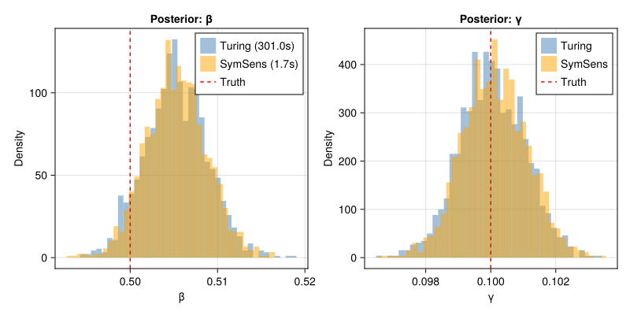

Figure 1: Posterior distributions from both approaches

```julia
fig = Figure(size=(800, 400))

ax1 = Axis(fig[1, 1]; xlabel="β", ylabel="Density", title="Posterior: β")
hist!(ax1, b1; bins=40, color=(:steelblue, 0.5), normalization=:pdf, label="Turing ($(round(t1.time; digits=0))s)")
hist!(ax1, b2; bins=40, color=(:orange, 0.5), normalization=:pdf, label="SymSens ($(round(t2.time; digits=1))s)")
vlines!(ax1, [0.5]; color=:red, linestyle=:dash, label="Truth")
axislegend(ax1; position=:rt)

ax2 = Axis(fig[1, 2]; xlabel="γ", ylabel="Density", title="Posterior: γ")
hist!(ax2, g1; bins=40, color=(:steelblue, 0.5), normalization=:pdf, label="Turing")
hist!(ax2, g2; bins=40, color=(:orange, 0.5), normalization=:pdf, label="SymSens")
vlines!(ax2, [0.1]; color=:red, linestyle=:dash, label="Truth")
axislegend(ax2; position=:rt)

fig
```

## Performance Summary

```julia
speedup = round(t1.time / t2.time; digits=0)

println("╔══════════════════════════════════════════════════════════════╗")
println("║                   Performance Comparison                    ║")
println("╠══════════════════════════════════════════════════════════════╣")
println("║ Approach                        │ Time   │ ESS/s(β)│iter/s ║")
println("╠═════════════════════════════════╪════════╪═════════╪═══════╣")
println("║ Turing + adjoint sensealg       │$(lpad(round(t1.time;digits=0),5))s │$(lpad(round(ess_ipse(b1)/t1.time;digits=1),7)) │$(lpad(round(2000/t1.time;digits=0),5))  ║")
println("║ SymSens + codegen + AdvancedHMC │$(lpad(round(t2.time;digits=1),5))s │$(lpad(round(ess_ipse(b2)/t2.time;digits=1),7)) │$(lpad(round(2000/t2.time;digits=0),5))  ║")
println("╠═════════════════════════════════╪════════╪═════════╪═══════╣")
println("║ Speedup                         │  $(lpad(speedup,3))×  │         │       ║")
println("╚══════════════════════════════════════════════════════════════╝")
```

```
╔══════════════════════════════════════════════════════════════╗
║                   Performance Comparison                    ║
╠══════════════════════════════════════════════════════════════╣
║ Approach                        │ Time   │ ESS/s(β)│iter/s ║
╠═════════════════════════════════╪════════╪═════════╪═══════╣
║ Turing + adjoint sensealg       │301.0s │    4.9 │  7.0  ║
║ SymSens + codegen + AdvancedHMC │  1.7s │  797.8 │1172.0  ║
╠═════════════════════════════════╪════════╪═════════╪═══════╣
║ Speedup                         │  176.0×  │         │       ║
╚══════════════════════════════════════════════════════════════╝
```

## Where Does the Speedup Come From?

### Key Insight

ModelingToolkit is best used as a **compile-time code generator**, not a runtime parameter-passing framework. The symbolic capabilities (Jacobians, sensitivity equations) are extremely powerful, but the high-level API adds overhead that dominates for fast-evaluating models. Extract the compiled functions and work with raw arrays for maximum performance.